# DATA624 Project-1

Gabriel Santos

2023-03-25

# Project - 1

This project consists of 3 parts - two required and one bonus and is worth 15% of your grade.

**Part A – ATM Forecast, ATM624Data.xlsx**

In part A, I want you to forecast how much cash is taken out of 4 different ATM machines for May 2010. The data is given in a single file. The variable ‘Cash’ is provided in hundreds of dollars, other than that it is straight forward. I am being somewhat ambiguous on purpose to make this have a little more business feeling. Explain and demonstrate your process, techniques used and not used, and your actual forecast. I am giving you data via an excel file, please provide your written report on your findings, visuals, discussion and your R code via an RPubs link along with the actual.rmd file Also please submit the forecast which you will put in an Excel readable file.

**Part B – Forecasting Power, ResidentialCustomerForecastLoad-624.xlsx**

Part B consists of a simple dataset of residential power usage for January 1998 until December 2013. Your assignment is to model these data and a monthly forecast for 2014. The data is given in a single file. The variable ‘KWH’ is power consumption in Kilowatt hours, the rest is straight forward. Add this to your existing files above.

**Part C – BONUS, optional (part or all), Waterflow_Pipe1.xlsx and Waterflow_Pipe2.xlsx**

Part C consists of two data sets. These are simple 2 columns sets, however they have different time stamps. Your optional assignment is to time-base sequence the data and aggregate based on hour (example of what this looks like, follows). Note for multiple recordings within an hour, take the mean. Then to determine if the data is stationary and can it be forecast. If so, provide a week forward forecast and present results via Rpubs and .rmd and the forecast in an Excel readable file.

# Libraries

```r
library(tidyverse)
library(ggplot2)
library(kableExtra)
library(gridExtra)
library(rio)
library(fpp2)
library(urca)
library(rio)
library(forecast)
library(lubridate)
library(dplyr)
```

# Part A – ATM Forecast

## Objetive

The goal of the project is to explore time series, decomposition, forecasting, data preprocessing, exponential smoothing, and ARIMA.

## Load Data

First, load the excel data, clean it by dropping the NA values, and rearrange it to a better format:

```r
atm <- import("https://raw.githubusercontent.com/GabrielSantos33/DATA624_Project1/main/ATM624Data.xlsx", col_types = c("date", "text", "numeric"))
atm_daily <- atm %>% drop_na() %>% spread(ATM, Cash)
atm_daily
```

```
##           DATE ATM1 ATM2 ATM3         ATM4
## 1   2009-05-01   96  107    0   776.993423
## 2   2009-05-02   82   89    0   524.417959
## 3   2009-05-03   85   90    0   792.811362
## 4   2009-05-04   90   55    0   908.238457
## 5   2009-05-05   99   79    0    52.832103
## 6   2009-05-06   88   19    0    52.208454
## 7   2009-05-07    8    2    0    55.473609
## 8   2009-05-08  104  103    0   558.503251
## 9   2009-05-09   87  107    0   904.341359
## 10  2009-05-10   93  118    0   879.493588
## 11  2009-05-11   86   75    0   274.022340
## 12  2009-05-12  111  111    0   396.108347
## 13  2009-05-13   75   25    0   274.547188
## 14  2009-05-14    6   16    0    16.321159
```

[output cut: 351 more lines]

According to the data in the table, we can see that the withdrawals from ‘ATM4’ are greater than the withdrawals from the other ATMs. In addition, the ‘ATM3’, most of the withdrawals are zero.

Generating the summary statistics and the boxplot:

```r
par(mfrow=c(4,1))
for (i in 2:5) {
  print(summary(atm_daily[i]))
}
```

```
##       ATM1
##  Min.   :  1.00
##  1st Qu.: 73.00
##  Median : 91.00
##  Mean   : 83.89
##  3rd Qu.:108.00
##  Max.   :180.00
##  NA's   :3
##       ATM2
##  Min.   :  0.00
##  1st Qu.: 25.50
##  Median : 67.00
##  Mean   : 62.58
##  3rd Qu.: 93.00
##  Max.   :147.00
##  NA's   :2
##       ATM3
##  Min.   : 0.0000
##  1st Qu.: 0.0000
##  Median : 0.0000
##  Mean   : 0.7206
##  3rd Qu.: 0.0000
##  Max.   :96.0000
##       ATM4
##  Min.   :    1.563
##  1st Qu.:  124.334
##  Median :  403.839
##  Mean   :  474.043
##  3rd Qu.:  704.507
##  Max.   :10919.762
```

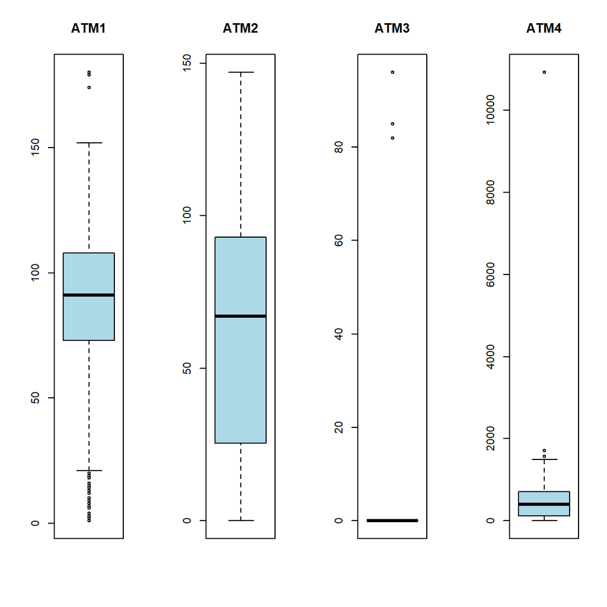

```r
par(mfrow=c(1,4))
for (i in 2:5){
    boxplot(atm_daily[i],
            main = sprintf("%s", names(atm_daily)[i]),
                  col="lightblue", width = 2)
}
```

From the above boxplots we see that ‘ATM1’ has numerous outliers, ‘ATM2’ has none, ‘ATM3’ has 3 (for every non-zero observation), and ‘ATM4’ has 3 outliers, one of which is quite extreme. . The transformation of outliers will be important for forecasting.